# Effects of altered snowmelt timing on flowering phenology of Arctic plant species

JJ Allaire https://github.com/jjallaire (RStudio)https://www.rstudio.com  
2022-09-23

# ABSTRACT

Climate change is driving rapid shifts in tundra vegetation. In Arctic regions, the climate is warming at more than twice the global average rate and patterns of precipitation have also been altered. This has major implications for the timing of phenophases of Arctic tundra plant species. Due to earlier snowmelt in many Arctic regions, flowering phenology may be advancing.

*Keywords*: phenology, climate change, Artic, tundra, plant ecology

# INTRODUCTION

Climate warming is driving rapid shifts in tundra vegetation (Arft *et al.* 1999). In particular, flowering phenology has been influenced (Collins *et al.* 2021), especially at colder, high latitude sites (Prevéy *et al.* 2017). This study uses data from Blume-Werry et al. (2017), accessed from Dryad, to plot flowering phenology of several Arctic plant species in Northern Sweden (Blume-Werry *et al.* 2017). An improved understanding of how species will react to altered snowmelt is imperative in tundra environments where environmental change is driving rapid shifts in vegetation.

# METHODS

In this study, snowmelt timing was manipulated by manually removing snow from experimental plots. Data was collected during the 2014 growing season in Northern Sweden near the Abisko Scientific Research Station (68°210 N18°450 E). This study was conducted in two contrasting heath and meadow plant communities. Researchers collected phenology data on 124 individual plants of several Arctic species across two treatment groups within 28 paired plots. For each individual plant, flowering phenology was recorded as the DOY (day of year) of the first mature flower and leaf phenology was recorded as the dDOY of the first mature leaf. In this paper, I subset the data to examine the flowering phenology, plotted as a function of snowmelt timing by species. For the purposes of this reproducible project, exploratory data analysis includes a simple plot.

# RESULTS

The flowering phenology was tightly coupled with snowmelt timing. All species showed a similar advancement in flowering phenology in response to earlier snowmelt (Fig. 1).

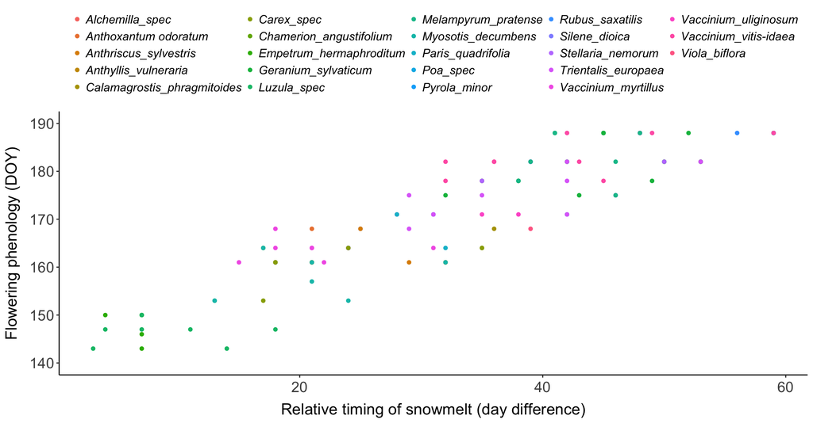

**Figure 1.** Flowering phenology as a function of snowmelt timing for 23 Arctic tundra species.

# DISCUSSION

Flowering phenology advanced with snowmelt date for all species observed in this study. This suggests that the timing of plant development is tightly coupled with the timing of snowmelt across the Arctic tundra. Unlike the phenological responses to climate warming, which are often species- or community-specific (Carbognani *et al.* 2018), this study shows that the flowering responses to snowmelt were strikingly similar for all species studied across two community types.

# CONCLUSION

Snowmelt strongly influences the timing of plant development. Since climate change is altering season patterns of snow accumulation and melt, the timing of life events for tundra species is expected to be altered.

# ACKNOWLEDGEMENTS

Thank you to the CIEE team for their guidance in creating a fully reproducible research project.

# DDATA AVAILABILITY STATEMENT

Data and reproducible code are freely available on GitHub at https://github.com/CIEE-Living-Data-Project/Rammell_BIOL548T_Phenology_Project_2022

# ORCID

Nicola F. Rammell (ID) https://orcid.org/0000-0002-3536-298X

# REFERENCES

Arft, A.M., Walker, M.D., Gurevitch, J., Alatalo, J.M., Bret-Harte, M.S., Dale, M., *et al.* (1999). Responses of Tundra Plants to Experimental Warming:meta-Analysis of the International Tundra Experiment. *Ecological Monographs*, 69, 491–511.

Blume-Werry, G., Jansson, R. & Milbau, A. (2017). [Root phenology unresponsive to earlier snowmelt despite advanced above-ground phenology in two subarctic plant communities](https://doi.org/10.1111/1365-2435.12853). *Functional Ecology*, 31, 1493–1502.

Carbognani, M., Tomaselli, M. & Petraglia, A. (2018). [Different temperature perception in high-elevation plants: New insight into phenological development and implications for climate change in the alpine tundra](https://doi.org/10.1111/oik.04908). *Oikos*, 127, 1014–1023.

Collins, C.G., Elmendorf, S.C., Hollister, R.D., Henry, G.H.R., Clark, K., Bjorkman, A.D., *et al.* (2021). [Experimental warming differentially affects vegetative and reproductive phenology of tundra plants](https://doi.org/10.1038/s41467-021-23841-2). *Nature Communications*, 12, 3442.

Prevéy, J., Vellend, M., Rüger, N., Hollister, R.D., Bjorkman, A.D., Myers-Smith, I.H., *et al.* (2017). [Greater temperature sensitivity of plant phenology at colder sites: Implications for convergence across northern latitudes](https://doi.org/10.1111/gcb.13619). *Global Change Biology*, 23, 2660–2671.